# Bulk RNA-seq differential expression analysis

Author

Prof. Francesca Finotello

# Guided analysis

In this exercise, we will analyze bulk RNA sequencing (RNA-seq) data generated with the [Illumina](https://www.illumina.com/) technology from human blood samples collected before and after influenza vaccination ([Hoek et al. Plos ONE, 2015](https://doi.org/10.1371/journal.pone.0118528)).

## Data access and initialization

Before running the analysis, we set a random seed to make plots reproducible, and we load the edgeR package needed for our investigation using the `library` function:

```r
set.seed(1234)
library(edgeR)
```

The RNA-seq expression data were downloaded from the [Gene Expression Omnibus (GEO)](https://www.ncbi.nlm.nih.gov/geo/) (data access: GSE64655). This data are available in the “Data” folder as a .TSV tab-delimited file, which can be imported in R as a data.frame with the `read.table` function:

```r
counts <- read.table(
  "../Data/GSE64655_raw_counts_GRCh38.p13_NCBI.tsv",
  header = TRUE,
  row.names = 1
)
```

**Warning**

The path to “Data” assumes a specific folder structure. Adjust it to match the location of the “Data” folder on your system (e.g., “/gpfs/gpfs1/scratch/c9881023/shared/Data”).

Let’s check the dimension of the count matrix and its first three rows and columns. The count matrix has ~40k genes and 56 samples. The samples are named according to GEO identifiers (e.g., “GSM1576391”) and [Ensembl](https://www.ensembl.org/index.html) gene identifiers (e.g., 100287102).

```r
dim(counts)
```

```
[1] 39376    56
```

```r
counts[1:3, 1:3]
```

```
          GSM1576391 GSM1576392 GSM1576393
100287102          8          6          8
653635          1091       1366       1363
102466751         37         57         36
```

We can import with `read.table` the full sample information from the tab-delimited file “GSE64655_annot.txt” available in the “Data” folder.

```r
annotation <- read.table("../Data/GSE64655_annot.txt",
                      header = TRUE)
```

**Warning**

The path to “Data” assumes a specific folder structure. Adjust it to match the location of the “Data” folder on your system (e.g., “/gpfs/gpfs1/scratch/c9881023/shared/Data”).

This table reports the GEO identifier of every sample (matching the count-matrix identifiers), together with a more interpretable sample name. Moreover, it reports the subject identifier, the day of sample collection (with day 0 representing pre-vaccination samples, and days 1, 3, and 7, the post-vaccination ones), and the sample type in terms of tissue/cell type.

```r
head(annotation)
```

```
      geo_id            sample subject day sample_type
1 GSM1576391  HD30_B_0_SL27200    HD30   0           B
2 GSM1576392  HD30_B_1_SL27207    HD30   1           B
3 GSM1576393  HD30_B_3_SL27214    HD30   3           B
4 GSM1576394  HD30_B_7_SL27221    HD30   7           B
5 GSM1576395 HD30_DC_0_SL27205    HD30   0          DC
6 GSM1576396 HD30_DC_1_SL27212    HD30   1          DC
```

We can check how many samples we have for every subject or cell types using the `table` function:

```r
table(annotation$subject)
```

```
HD30 HD31
  28   28
```

```r
table(annotation$sample_type)
```

```
   B   DC   MO  NEU   NK PBMC    T
   8    8    8    8    8    8    8
```

Before we use this data for the analysis, let’s make sure that we consider exactly the same samples (in the same order) of the gene-expression data:

```r
counts <- counts[, annotation$geo_id]
```

## Exploratory data analysis

Before analyzing differential gene expression, let’s perform principal component analysis (PCA) of the whole dataset. To correct library size and data skewness, we will convert the raw gene counts to log-scaled counts per millions (CPM), using a prior count of 1 to avoid non-finite values (i.e., we compute log(CPM+1)):

```r
log_cpm <- cpm(counts,
               log = TRUE,
               prior.count = 1)
```

We can now perform PCA using the `prcomp` function, and extract the first two principal components (PC1 and PC2) from `pca_result$x`:

```r
pca_result <- prcomp(t(log_cpm))
pc1 <- pca_result$x[, 1]
pc2 <- pca_result$x[, 2]
```

The results of `prcomp` also contain the standard deviation accounted by every PC (`pca_result$sdev`) which can be used to compute the percentage of total variance explained by each PC:

```r
pca_var <- (pca_result$sdev^2) / sum(pca_result$sdev^2) * 100
var1 <- round(pca_var[1], 1)
var2 <- round(pca_var[2], 1)
```

We can now make a PCA plot to show all the samples in PCA space, also reporting the percentage of variance explained by PC1 and PC2 on their respective axis:

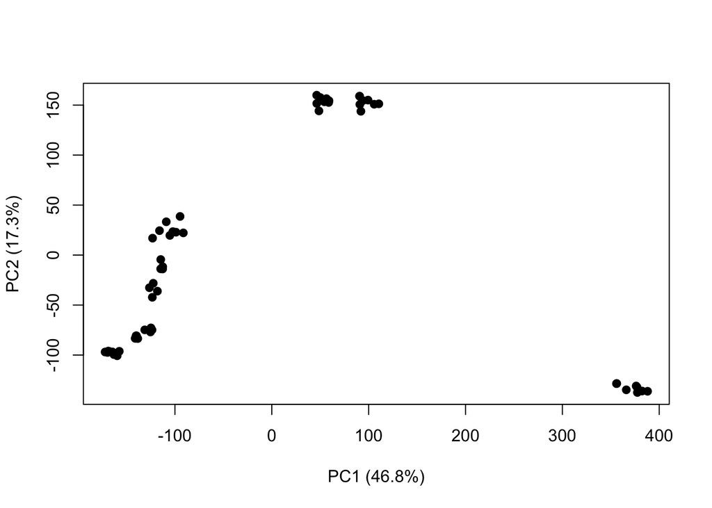

```r
plot(
  pc1, pc2,
  pch = 19,
  xlab = paste0("PC1 (", var1, "%)"),
  ylab = paste0("PC2 (", var2, "%)")
)
```

By defining a palette based on two colors, we can color the points according to the subject (`annotation$subject`):

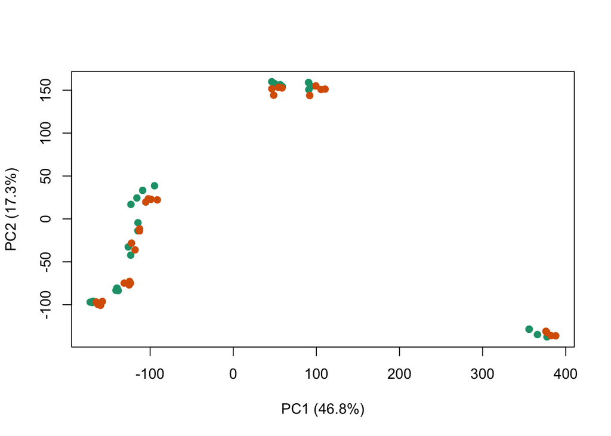

```r
cols <- c("#1b9e77", "#d95f02")
classes <- factor(annotation$subject)
plot(
  pc1, pc2,
  pch = 19,
  xlab = paste0("PC1 (", var1, "%)"),
  ylab = paste0("PC2 (", var2, "%)"),
  col = cols[classes]
)
```

To be able to interpret the results, we need to add a legend:

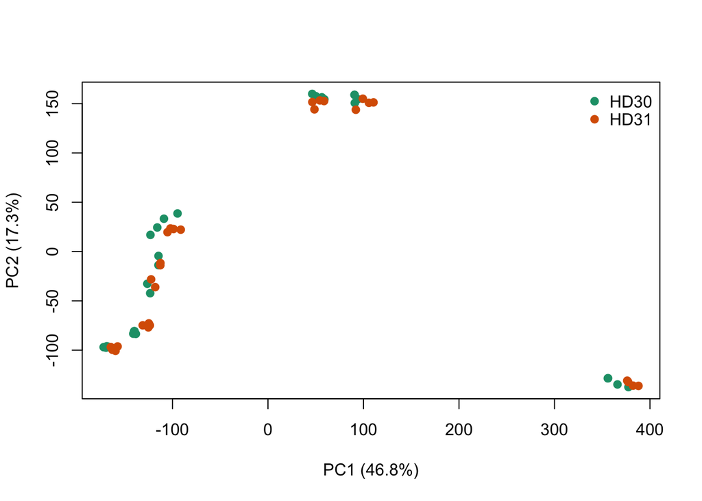

```r
plot(
  pc1, pc2,
  pch = 19,
  xlab = paste0("PC1 (", var1, "%)"),
  ylab = paste0("PC2 (", var2, "%)"),
  col = cols[classes]
)
legend(
  "topright",
  legend = levels(classes),
  col = cols,
  pch = 19,
  bty = "n",
  y.intersp = 0.9 # Controls the vertical distance between
                  # legend elements; fix as you wish
)
```

❓ **Question:** Do the samples from the two patients separate along PC1 and/or PC2?

Let’s color the PCA plot instead according to the day. To be able to consider also other covariates with more classes, let’s first define a palette with seven colors:

```r
cols <- c(
  "#1b9e77",
  "#d95f02",
  "#7570b3",
  "#e7298a",
  "#66a61e",
  "#e6ab02",
  "#a6761d"
)
```

Now we can adapt the code above to color the PCA plot according to the *day*:

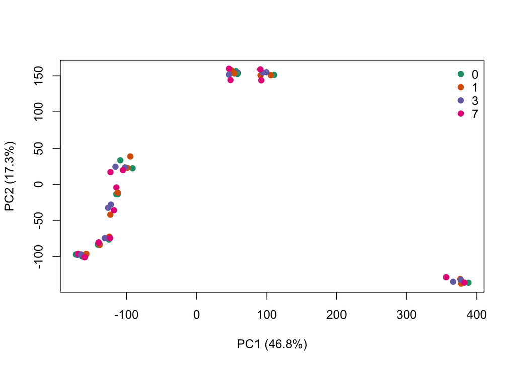

```r
classes <- factor(annotation$day)
plot(
  pc1, pc2,
  pch = 19,
  xlab = paste0("PC1 (", var1, "%)"),
  ylab = paste0("PC2 (", var2, "%)"),
  col = cols[classes]
)
legend(
  "topright",
  legend = levels(classes),
  col = cols,
  pch = 19,
  bty = "n",
  y.intersp = 0.9
)
```

## Data preparation

We want to change Ensembl gene names to more interpretable gene names/symbols. To do so, we can leverage a .TSV file containing the gene name-Ensembl correspondences for the genes of the GRCh38 human genome.

```r
geneinfo <- read.delim("../Data/Human.GRCh38.p13.annot.tsv")
geneinfo <- geneinfo[, c("GeneID", "Symbol")]
head(geneinfo)
```

```
     GeneID      Symbol
1 100287102     DDX11L1
2    653635      WASH7P
3 102466751   MIR6859-1
4 107985730 MIR1302-2HG
5 100302278   MIR1302-2
6    645520     FAM138A
```

Of note, there is no 1:1 correspondence between Ensembl gene identifiers (`GeneID`) and gene symbols but, actually, different `GeneID` can be associated to the same `Symbol`:

```r
length(unique(geneinfo$GeneID))
```

```
[1] 39376
```

```r
length(unique(geneinfo$Symbol))
```

```
[1] 39374
```

```r
sum(duplicated(geneinfo$GeneID))
```

```
[1] 0
```

```r
sum(duplicated(geneinfo$Symbol))
```

```
[1] 2
```

❓ **Question:** How many gene symbols are duplicated in the `geneinfo` table?

We can use the following code to: 1) Sort the genes in the count table according to their median expression across samples, so to have the ones with the higher expression on top; 2) Match these genes to the Ensembl identifiers in the `geneinfo` and select only those for which gene symbol information is not `NA`, and which are not duplicated; 3) Select only those genes in the count matrix and `geneinfo` annotation (to keep them aligned) and rename them according to gene symbols.

```r
# Sort genes by median expression (descending)
srt_rows <- order(apply(counts, 1, median), decreasing = TRUE)
counts <- counts[srt_rows, ]

# Match GeneID to the rows of counts
geneinfo <- geneinfo[match(rownames(counts), geneinfo$GeneID), ]
keep <- !is.na(geneinfo$Symbol) & !duplicated(geneinfo$Symbol)

# Select the final genes and replace Entrez IDs with gene symbols
geneinfo <- geneinfo[keep, ]
counts <- counts[keep, ]
rownames(counts) <- geneinfo$Symbol
```

Let’s save this updated version of `counts` together with the associated sample annotations saved in `annotation` in a file called `GSE64655.rda`:

```r
save(counts, annotation,
     file = "GSE64655.rda")
```

**Warning**

Adapt the file path of the code above to save the file in your directory of choice, where you have writing access.

## Data selection

In this exercise, we want to compare the transcriptomic profiles of peripheral blood mononuclear cell (PBMC) samples 7 days after vaccination vs. day 0 (pre-vaccination). To do so, we need to select from the `annotation` and `counts` objects the correct samples. In this step, we can also rename the columns of the count matrix with the more interpretable sample identifiers available from the `annotation_sel` object.

```r
idx <- intersect(
  which(annotation$sample_type == "PBMC"),   # indexes of PBMC samples
  which(annotation$day %in% c(0, 7))         # indexes of samples from days 0 or 7
)
annotation_sel <- annotation[idx, ]
counts_sel <- counts[, annotation_sel$geo_id]
colnames(counts_sel) <- annotation_sel$sample
```

## Differential expression analysis

In this step, we will perform differential expression (DE) analysis with the [edgeR R package](https://bioconductor.org/packages/release/bioc/html/edgeR.html).

**Important note:** the sample size of this dataset, with only two samples per group, is too small to gather robust insights on the impact of influenza vaccination on PBMC. Furthermore, as the pre- and post-vaccination samples come from the same two patients, an ideal analysis would keep into consideration this *paired* design. Despite these limitations, the following analysis can serve as a first introduction to DE analysis with edgeR, as well as with its downstream interpretation and visualization.

We start by defining the two groups that we want to consider: “pre” for day 0 (pre-vaccination) and “post” for day 7 post-vaccination. Specifically, we create a vector that stores, for every sample, whether it belongs to the “pre” or “post” group. To do so, we use the `ifelse` function that takes the `annotation_sel$day` information and check, for every element, if it is equal to 0 (`==0`); if true, that element is converted to “pre”, if false, to “post”. We further use the `factor` function to convert this vector of characters into a vector of factors, and `relevel` to make sure that the “pre” condition is considered as the *reference* (i.e., we want to assess the effect of vaccination compared to the pre-vaccination settings).

```r
group <- ifelse(annotation_sel$day == 0, "pre", "post")
group <- factor(group)
group <- relevel(group, ref = "pre")
```

To perform DE analysis, edgeR needs a *design matrix* for the linear model that is used internally, to be specified with an R’s formula syntax. In our case, we can create the design matrix to compare the two `groups` using the following code:

```r
design <- model.matrix(~group)
```

edgeR also requires to save the `counts_sel` and `group` information into a specific data format using the `DGEList` function:

```r
y <- DGEList(counts = counts_sel, group = group)
class(y)
```

```
[1] "DGEList"
attr(,"package")
[1] "edgeR"
```

We now want to filter out lowly-expressed genes using edgeR’s `filterByExpr` function, and normalize the data to account for differences in library sizes (`normLibSizes`).

```r
keep <- filterByExpr(y, design)
y <- y[keep, , keep.lib.sizes = TRUE]
y <- normLibSizes(y)
```

We now estimate gene-wise dispersion (`estimateDisp`), fit a negative binomial GLM to each gene (`glmFit`), and test for differential expression using a likelihood ratio test (`glmLRT`). In simple terms, we measure how variable each gene’s counts are across samples, model the relationship between expression and group, and identify which genes are significantly different between conditions.

```r
y <- estimateDisp(y, design)
fit <- glmFit(y, design)
lrt <- glmLRT(fit)
```

We can now extract the full ranked results table with `topTags`, specifying that we want all genes present in `y` (`n = nrow(y)`), reformat it into a data.frame, and inspect the top 20 genes in this data.frame:

```r
DEGs <- topTags(lrt, n = nrow(y))
DEGs <- data.frame(Gene = rownames(DEGs), DEGs)
head(DEGs, 20)
```

```
             Gene    logFC     logCPM       LR       PValue          FDR
IGLJ2       IGLJ2 2.549686  3.7054951 61.91782 3.580933e-15 6.703507e-11
IGLV2-23 IGLV2-23 1.632943  3.6854651 49.20340 2.307509e-12 2.157659e-08
IGLC2       IGLC2 2.691239  7.4317188 48.20877 3.831716e-12 2.157659e-08
IGLC3       IGLC3 2.051638  6.8887029 47.84604 4.610382e-12 2.157659e-08
IGHG1       IGHG1 3.913200  8.8863122 46.32685 1.000829e-11 3.747105e-08
IGLV1-36 IGLV1-36 2.569232  1.6909442 44.03802 3.220589e-11 1.004824e-07
IGLV3-21 IGLV3-21 4.119720  5.6780023 40.63092 1.838741e-10 4.917319e-07
ELK2AP     ELK2AP 3.274499  2.9241722 40.13432 2.370864e-10 5.547821e-07
HBQ1         HBQ1 4.515105 -0.0816109 37.75043 8.039920e-10 1.558365e-06
IGHGP       IGHGP 3.562774  5.7740747 37.68255 8.324600e-10 1.558365e-06
IGLV1-47 IGLV1-47 1.813968  2.9822032 33.21715 8.242045e-09 1.402646e-05
IGLJ3       IGLJ3 1.756118  2.5170957 31.84056 1.673608e-08 2.610829e-05
IGLV3-10 IGLV3-10 2.485730  1.0092343 29.47383 5.667693e-08 8.161478e-05
IGLV2-34 IGLV2-34 2.183064  1.0520017 29.12741 6.777129e-08 8.545595e-05
IGHG4       IGHG4 2.930273  5.5848654 29.10742 6.847432e-08 8.545595e-05
IGLV1-44 IGLV1-44 2.580709  3.9457712 28.49581 9.390153e-08 1.098648e-04
IGLV3-1   IGLV3-1 2.275749  3.0190317 27.39409 1.659374e-07 1.827264e-04
IGHV4-39 IGHV4-39 1.683804  2.7135847 24.34693 8.045480e-07 8.367299e-04
IGLV2-18 IGLV2-18 1.983544  1.6104796 23.99641 9.651561e-07 9.509327e-04
IGLC6       IGLC6 2.376498  3.5463088 23.48861 1.256557e-06 1.176137e-03
```

We want now to select the top differentially expressed genes, considering a level of significance of 10% on p-values adjusted for multiple testing (i.e., `FDR` column). How many differentially expressed (DE) genes do we have?

```r
alpha <- 0.1
totDE <- sum(DEGs$FDR < alpha)
cat("We have", totDE, "DE genes\n")
```

```
We have 30 DE genes
```

How many up-regulated genes in post- vs. pre-vaccination samples?

```r
totUp <- sum(DEGs$FDR < alpha & DEGs$logFC > 0)
cat("We have", totUp, "up-regulated genes\n")
```

```
We have 29 up-regulated genes
```

Write the code to count the number of down-regulated genes.

# Homework

The aim of this homework exercise is to perform analysis similar to the guided analysis above. To this end, let’s load again the prepared `counts` and `annotation` information that we saved in “GSE64655.rda”:

```r
load("GSE64655.rda")
```

**Warning**

Adapt the file path of the code above to load the file from the directory where you saved it.

Let’s proceed with PCA analysis, following the steps we implemented above: 1) normalization to log-CPM, PCA analysis and calculation of the variance explained by PC1 and PC2, and visualization. **Note:** we are using a slightly different dataset compared to the previous analysis, as we re-mapped to gene names and removed duplicates; these small changes will *not* result in big changes in the PCA plot.

Let’s color the PCA-plot (PC1 vs. PC2) according to

- subject (`annotation$subject`)
- day (`annotation$day`)
- sample type (`annotation$sample_type`)

using the palette below or one of your choice:

```r
pal <- c(
  "#1b9e77",
  "#d95f02",
  "#7570b3",
  "#e7298a",
  "#66a61e",
  "#e6ab02",
  "#a6761d"
)
```

❓ **Question:** Which covariate among *subject*, *day*, and *sample_type* explains better sample separation in the PCA plot?

In this exercise, we want to compare the transcriptomic profiles of B cell samples 7 days after vaccination vs. day 0 (pre-vaccination). To do so, we need to select from the `annotation` and `counts` objects the correct samples, similarly to what we did above. As before, we can rename the columns of the count matrix with the more interpretable sample identifiers. The reworked `counts_sel` matrix and `annotation_sel` objects should encompass the following samples:

```r
colnames(counts_sel)
```

```
[1] "HD30_B_0_SL27200" "HD30_B_7_SL27221" "HD31_B_0_SL17288" "HD31_B_7_SL17312"
```

```r
annotation_sel$sample
```

```
[1] "HD30_B_0_SL27200" "HD30_B_7_SL27221" "HD31_B_0_SL17288" "HD31_B_7_SL17312"
```

Let’s now perform DE analysis with edgeR to compare B-cell profiles at day 7 (post-vaccination) vs. day 0 (pre-vaccination). Follow the steps defined in the guided exercise: 1) definition of group and design matrix, 2) creation of the “DGEList” object and filtering of lowly-expressed genes, 3) data normalization, 4) estimation of dispersion, 5) DE testing.

❓ **Question:** If we accept a false-discovery rate of 10%, how many up-regulated DE genes do we identify? How many down-regulated? How do you interpret them biologically in the context of influenza vaccination and B-cell biology?